# Doing Data Science Case Study 2

Joshua Yi & Grant Bourzikas

November 24, 2018

### **Introduction**

Yi & Bourzikas specializes in talent management solutions for Fortune 1000 companies focus on building and developing strategies for retaining employees. We specialize in workforce planning, employee training programs, identifying high-potential employees and reducing/preventing voluntary employee turnover (attrition). As part of this engagement, our data science team will predict for your organization.

```r
# Josh Path
#employee <- read.csv("E:/Documents/School/MSDS 6306/Case Study 2/CaseStudy2-data.csv", na.strings = "NULL")
#employeeValidation <- read.csv("E:/Documents/School/MSDS 6306/Case Study 2/CaseStudy2Validation.csv", na.strings = "NULL")
#Grant Path
employee <- read.csv("/Users/gbourzik/OneDrive - McAfee/Documents/SMU/6306 - DDS - F18/Case_Final2/SMU-MSDS-Homework/Case Study 2/CaseStudy2-data.csv", na.strings = "NULL")
employeeValidation <- read.csv("/Users/gbourzik/OneDrive - McAfee/Documents/SMU/6306 - DDS - F18/Case_Final2/SMU-MSDS-Homework/Case Study 2/CaseStudy2Validation.csv", na.strings = "NULL")
result <-rbind(employee,employeeValidation)
```

```r
#Create 1/0 from Catagorical Variables
emp_train <- fastDummies::dummy_cols(employee) # Create Dummy Variables
emp_test <- fastDummies::dummy_cols(employeeValidation) # Create Dummy Variables
emp_result <- rbind(emp_test, emp_test) # combine train and test data sets
```

```r
# Creating Variables
# Define Data Colums to Make it Easier
cols.Base <- c(2:36)
cols.CatAttr <- c(38:39)
cols.CatAll <- c(40:68)
col.NoJobRole <- c(1,2,5,7,8,10,12,14,15,18,20,21,22,25:36,38:42,52:53,63:68)
# Removed 17 From Data Set
cols.RemoveJobRoleCat <- c(1,2,3,4,5,6,7,8,9,10,11,12,13,14,15,16,18,19,20,21,22,66,24,25,26,27,28,29,30,31,32,33,34,35,36)
# All Job Detailed Roles
cols.JobRoles <- c(54:62)
cols.AllButAttr <- c(1,2,3,4,5,6,7,8,9,10,11,12,13,14,15,16,17,18,19,20,21,22,24,25,26,27,28,29,30,31,32,33,34,35,36,40,41,42,43,44,45,46,47,48,49,50,51,52,53,63,64,65,66,67,68)
# This is all the Catagorical Fields
cols.CatGLM <- c(1,2,3,4,5,6,7,8,9,10,11,12,13,14,15,16,17,18,19,20,21,22,66,24,25,26,27,28,29,30,31,32,33,34,35,36)
cols.CatKNN <- c(1,2,3,5,7,8,10,11,12,14,15,16,18,20,21,22,25,26,27,28,29,30,31,32,33,34,35,36,40,41,42,43,44,45,46,47,48,49,50,51,52,53,54,55,56,57,58,59,60,61,62,63,64,65,66,67,68)
cols.NumericAll <- c(1,2,5,7,8,10,11,12,14,15,16,18,20,21,22,25,26,27,28,29,30,31,32,33,34,35,36,40,41,42,43,44,45,46,47,48,49,50,51,52,53,54,55,56,57,58,59,60,61,62,63,64,65,66,67,68)
cols.Attrition <- 34
cols.KeyFieldsBaseModel <- c(40:42,7,12,63:65,22,67:68,27,30,31:36)
```

We received the data files from your employee database and have outlined some key highlights. The following charts are part of our exploratory data and will give your organization an idea of how different features in the data set apply. The pair plots show all the variables based on whether your employees have left the organisation.

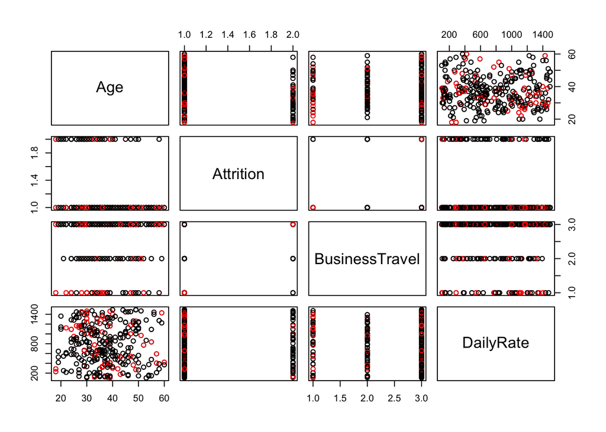

```r
# Basic EDA
#EDA - Exploratory Not for Report
pairs(emp_result[,c(2:5)], col=emp_train$Attrition)
```

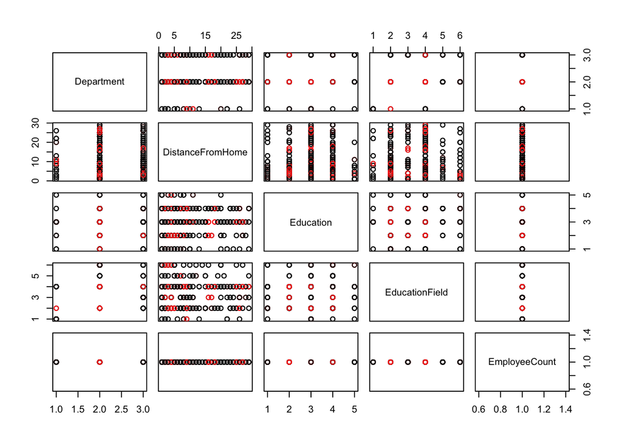

```r
pairs(emp_result[,c(6:10)], col=emp_train$Attrition)
```

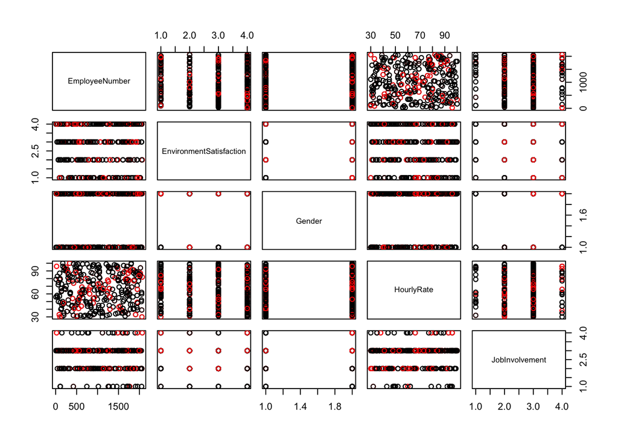

```r
pairs(emp_result[,c(11:15)], col=emp_train$Attrition)
```

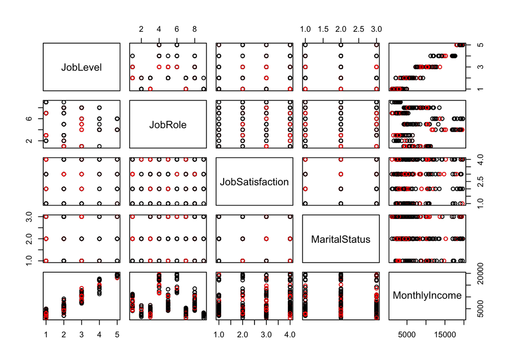

```r
pairs(emp_result[,c(16:20)], col=emp_train$Attrition)
```

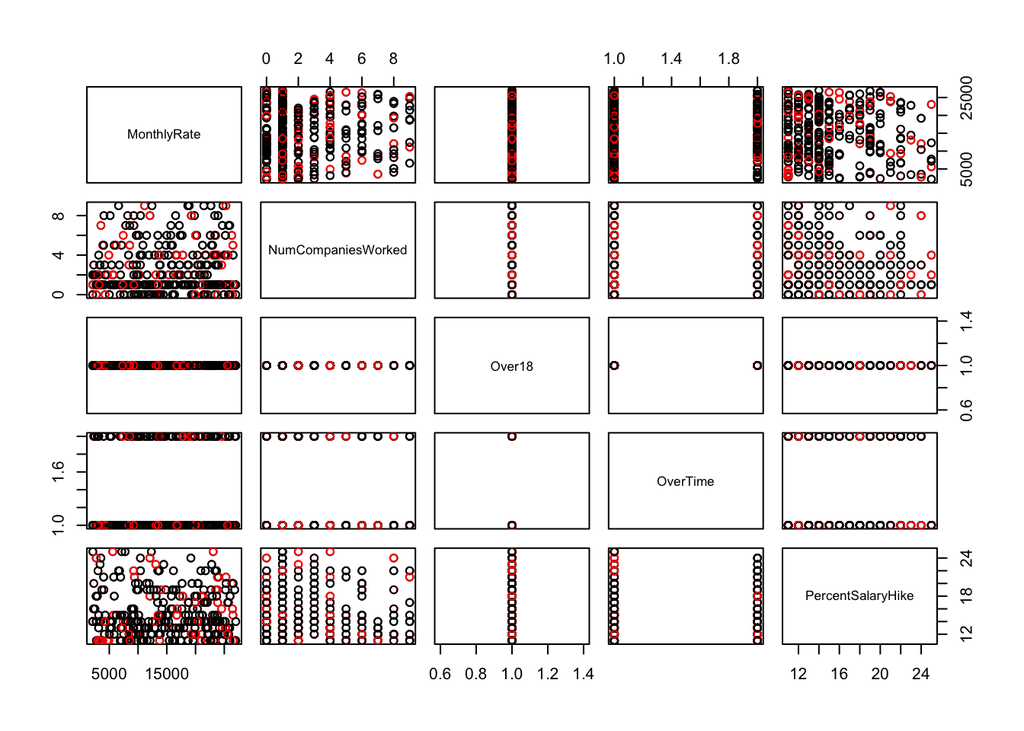

```r
pairs(emp_result[,c(21:25)], col=emp_train$Attrition)
```

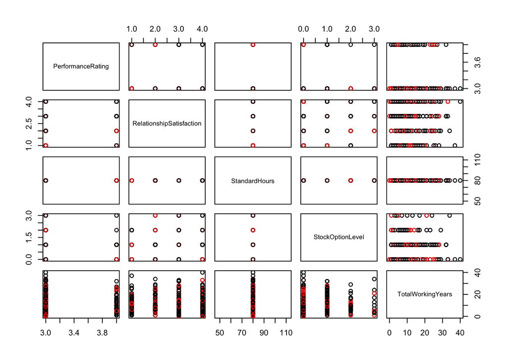

```r
pairs(emp_result[,c(26:30)], col=emp_train$Attrition)
```

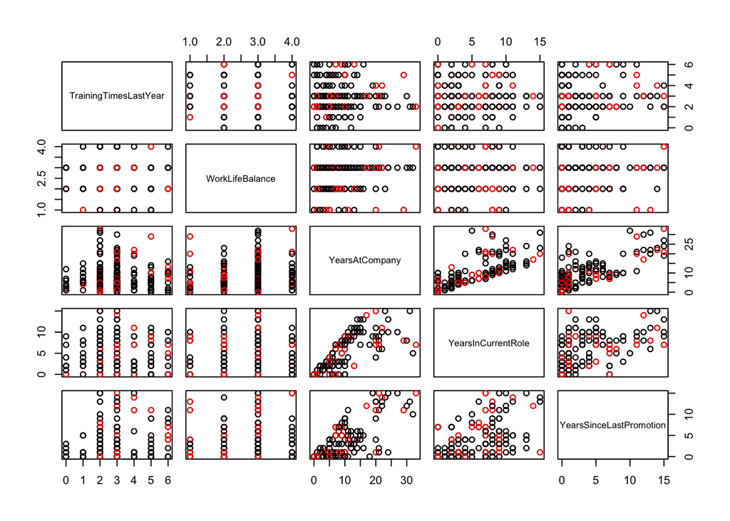

```r
pairs(emp_result[,c(31:35)], col=emp_train$Attrition)
```

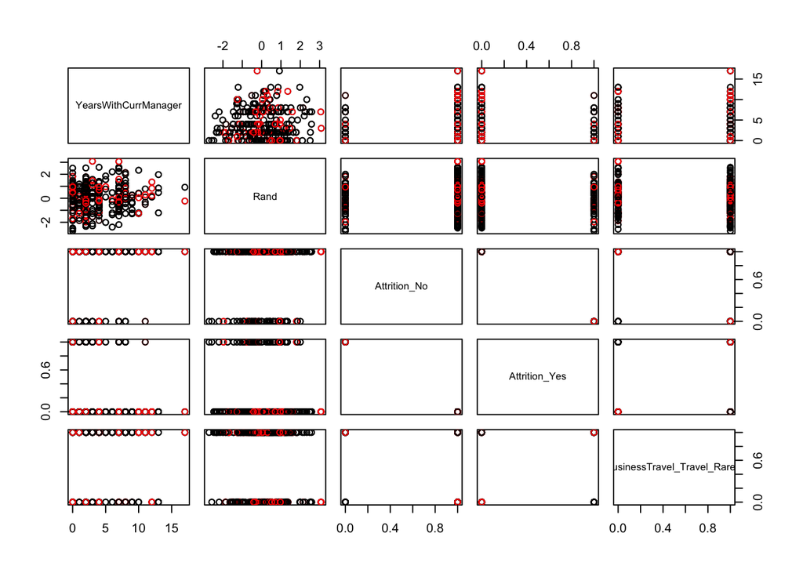

```r
pairs(emp_result[,c(36:40)], col=emp_train$Attrition)
```

```r
#No Data in Plots
#pairs(emp_result[,c(41:45)], col=emp_train$Attrition)
#pairs(emp_result[,c(46:50)], col=emp_train$Attrition)
#pairs(emp_result[,c(51:55)], col=emp_train$Attrition)
##pairs(emp_result[,c(56:60)], col=emp_train$Attrition)
#pairs(emp_result[,c(61:68)], col=emp_train$Attrition)
```

#### *Heat Map Charts*

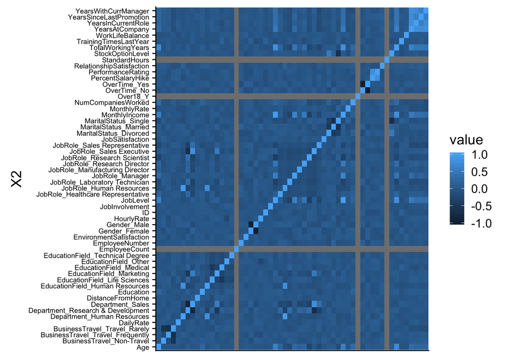

```r
# Heat Map for All Fields
employeeHeatMap <- round(cor(emp_result[,c(cols.NumericAll)]),2)
melted_employeeHeatMap <- melt(employeeHeatMap)
ggplot(data = melted_employeeHeatMap, aes(x=X1, y=X2, fill=value)) +
  theme(axis.text.x  = element_blank(),axis.ticks.x=element_blank(),axis.title.x=element_blank(),axis.text.y  = element_text(size = 7))+geom_tile()
```

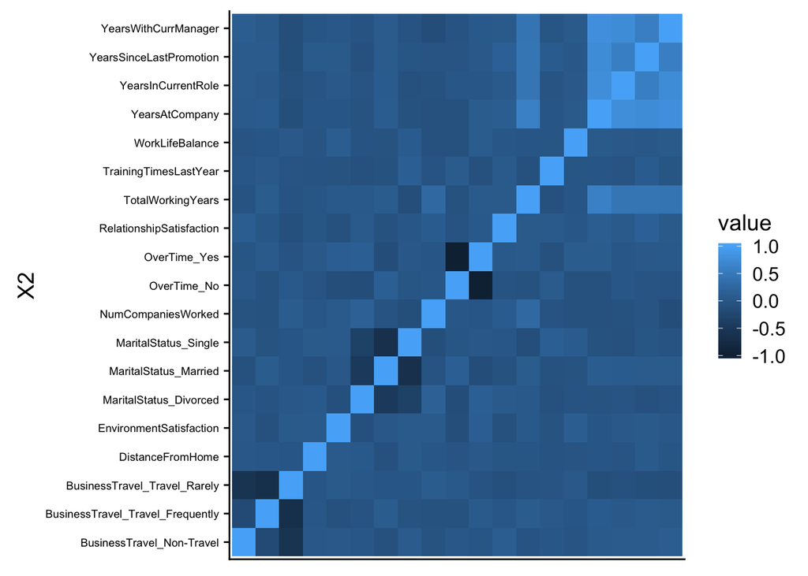

```r
#ggsave("images/employeeHeatMap.png",plot = last_plot(), type = png())
# Heat Map for Key Sign Fields
employeeHeatMapSig <- round(cor(emp_result[,c(cols.KeyFieldsBaseModel)]),2)
melted_employeeHeatMapSig <- melt(employeeHeatMapSig)
ggplot(data = melted_employeeHeatMapSig, aes(x=X1, y=X2, fill=value)) +
  theme(axis.text.x  = element_blank(),axis.ticks.x=element_blank(),axis.title.x=element_blank(),axis.text.y  = element_text(size = 7))+
  geom_tile()
```

```r
#ggsave("images/employeeHeatMapSig.png",plot = last_plot(), type = png())
# EDA For Key Sign Fields on Attrition for Overall Model
ggkeySignPairs <- ggpairs(
  mapping = ggplot2::aes(color = emp_result$Attrition),
  emp_result[,c(cols.KeyFieldsBaseModel)],
  diag=list(continuous="densityDiag", discrete="barDiag"),
  axisLabels="show") + theme_minimal()
#ggsave("ggkeySignPairs.png",plot = last_plot(), type = png())
```

#### *Signficant Key Factor attributing to Attirtion*

Showing the significance, p-values, for each variable. This is the base information to understand the key contributors that affect attrition. This data will be used through our data science work so we can utilize the following variables for the models we build.

The following table outlines the top significant factors contributing to attrition:

```r
#TrainDataSet
glm_modeltrain <- glm(emp_train$Attrition~.,emp_train[,c(cols.CatGLM)], family = binomial) # glm train
model_Train = data.frame(coef(summary(glm_modeltrain))[,4]) # pvalue from glm train
names(model_Train) = "GLM Training Set" # title
#TestDataSet
glm_modeltest <- glm(emp_test$Attrition~.,emp_test[,c(cols.CatGLM)], family = binomial) # glm test
model_Test = data.frame(coef(summary(glm_modeltest))[,4]) # pvalue from glm test
names(model_Test) = "GLM Test Set" # title
#AllData
glm_modelAll <- glm(emp_result$Attrition~.,emp_result[,c(cols.CatGLM)], family = binomial) # glm for all combined test and train data set
model_All = data.frame(coef(summary(glm_modelAll))[,4]) # pvalue fro combined data set
names(model_All) = "GLM All Set" # title
# Table consolidated
GLM_dataset <-cbind(model_Train, model_Test,model_All) # consolidated train, test and all data set
# Creating kable table for GLM dataset
GLM_dataset  %>%  kable() %>% kable_styling(bootstrap_options = "striped", full_width = F) %>% scroll_box(width = "600px", height = "450px")
```

|  | GLM Training Set | GLM Test Set | GLM All Set |
| --- | --- | --- | --- |
| (Intercept) | 0.9856239 | 0.9989900 | 0.9985716 |
| ID | 0.7413226 | 0.5564256 | 0.4055318 |
| Age | 0.2081840 | 0.0156765 | 0.0006326 |
| BusinessTravelTravel_Frequently | 0.0000674 | 0.0010245 | 0.0000034 |
| BusinessTravelTravel_Rarely | 0.0257045 | 0.0164520 | 0.0006930 |
| DailyRate | 0.1137743 | 0.0637612 | 0.0087484 |
| DepartmentResearch & Development | 0.9840834 | 0.9999149 | 0.9998797 |
| DepartmentSales | 0.9855939 | 0.9982575 | 0.9975358 |
| DistanceFromHome | 0.0003241 | 0.0022409 | 0.0000154 |
| Education | 0.8266214 | 0.1306817 | 0.0325598 |
| EducationFieldLife Sciences | 0.9750329 | 0.3202993 | 0.1598708 |
| EducationFieldMarketing | 0.8437994 | 0.5521055 | 0.4004024 |
| EducationFieldMedical | 0.9098803 | 0.2537434 | 0.1065171 |
| EducationFieldOther | 0.6960025 | 0.9285191 | 0.8990460 |
| EducationFieldTechnical Degree | 0.4683605 | 0.4508936 | 0.2863276 |
| EmployeeNumber | 0.9027209 | 0.4249982 | 0.2592223 |
| EnvironmentSatisfaction | 0.0000007 | 0.0800222 | 0.0132989 |
| GenderMale | 0.0660375 | 0.1909220 | 0.0643729 |
| HourlyRate | 0.2337414 | 0.3492105 | 0.1855442 |
| JobInvolvement | 0.0000060 | 0.8371013 | 0.7712302 |
| JobLevel | 0.3421974 | 0.0316539 | 0.0023752 |
| JobRoleHuman Resources | 0.9829785 | 0.9981111 | 0.9973286 |
| JobRoleLaboratory Technician | 0.0127075 | 0.9921081 | 0.9888393 |
| JobRoleManager | 0.8653399 | 0.9989564 | 0.9985241 |
| JobRoleManufacturing Director | 0.8918567 | 0.9931527 | 0.9903166 |
| JobRoleResearch Director | 0.0349614 | 0.9909768 | 0.9872395 |
| JobRoleResearch Scientist | 0.8565130 | 0.9923366 | 0.9891625 |
| JobRoleSales Executive | 0.1372067 | 0.9999902 | 0.9999861 |
| JobRoleSales Representative | 0.0299926 | 0.9995330 | 0.9993395 |
| JobSatisfaction | 0.0000192 | 0.0068582 | 0.0001315 |
| MaritalStatusMarried | 0.0601860 | 0.4269320 | 0.2612143 |
| MaritalStatusSingle | 0.0008135 | 0.1077738 | 0.0229388 |
| MonthlyIncome | 0.2085435 | 0.0074394 | 0.0001536 |
| MonthlyRate | 0.4484720 | 0.0070837 | 0.0001399 |
| NumCompaniesWorked | 0.0000051 | 0.0129331 | 0.0004395 |
| OverTimeYes | 0.0000000 | 0.0000101 | 0.0000000 |
| PercentSalaryHike | 0.6585720 | 0.5792289 | 0.4329243 |
| PerformanceRating | 0.7420886 | 0.0477017 | 0.0051076 |
| RelationshipSatisfaction | 0.0363799 | 0.0009600 | 0.0000030 |
| StockOptionLevel | 0.2540503 | 0.7718614 | 0.6817778 |
| TotalWorkingYears | 0.0141019 | 0.6265806 | 0.4914031 |
| TrainingTimesLastYear | 0.0335913 | 0.2194417 | 0.0824447 |
| WorkLifeBalance | 0.0006481 | 0.7803786 | 0.6933455 |
| YearsAtCompany | 0.0107927 | 0.1789009 | 0.0573137 |
| YearsInCurrentRole | 0.0034318 | 0.0492443 | 0.0054190 |
| YearsSinceLastPromotion | 0.0000925 | 0.0064181 | 0.0001159 |
| YearsWithCurrManager | 0.0131109 | 0.0292065 | 0.0020427 |

#### *Basic Regrewssion for each Job Role*

Learning about any job role specific trends that may exist in the data set is key because it tells us which variables are significant by job. This data can be used to identify what affects will contribute to attrition rate by job. Any value that is < 0.5 is significant

```r
# Glm for Job role - Human Resources
glm_model_JobRoleHR <- glm(emp_result$`JobRole_Human Resources`~.,emp_result[,c(col.NoJobRole)], family = binomial) # glm
JobRoleHR = data.frame(coef(summary(glm_model_JobRoleHR))[,4]) # pulling only pvalue from the glm
names(JobRoleHR) = "Human Resources" # creating title
# Glm for Job role - Manufactoring Director
glm_model_JobRoleManufactoring <- glm(emp_result$`JobRole_Manufacturing Director`~.,emp_result[,c(col.NoJobRole)], family = binomial)# glm
JobRoleManufactoring = data.frame(coef(summary(glm_model_JobRoleManufactoring))[,4])# pulling only pvalue from the glm
names(JobRoleManufactoring) = "Manufacturing Director" # creating title
# Glm for Job role - Research Scientist
glm_model_JobRoleResearch <- glm(emp_result$`JobRole_Research Scientist`~.,emp_result[,c(col.NoJobRole)], family = binomial)# glm
JobRoleResearch = data.frame(coef(summary(glm_model_JobRoleResearch))[,4])# pulling only pvalue from the glm
names(JobRoleResearch) = "Research Scientist" # creating title
# Glm for Job role - Lab Tech
glm_model_JobRoleLab <- glm(emp_result$`JobRole_Laboratory Technician`~.,emp_result[,c(col.NoJobRole)], family = binomial)# glm
JobRoleLab = data.frame(coef(summary(glm_model_JobRoleLab))[,4])# pulling only pvalue from the glm
names(JobRoleLab) = "Laboratory Technician" # creating title
# Glm for Job role - Research Director
glm_model_JobRoleResearchDirector <- glm(emp_result$`JobRole_Research Director`~.,emp_result[,c(col.NoJobRole)], family = binomial)# glm
JobRoleRD = data.frame(coef(summary(glm_model_JobRoleResearchDirector))[,4])# pulling only pvalue from the glm
names(JobRoleRD) = "Research Director" # creating title
# Glm for Job role - Sales Exec
glm_model_JobRoleSalesExec <- glm(emp_result$`JobRole_Sales Executive`~.,emp_result[,c(col.NoJobRole)], family = binomial)# glm
JobRoleSE = data.frame(coef(summary(glm_model_JobRoleSalesExec))[,4])# pulling only pvalue from the glm
names(JobRoleSE) = "Sales Executive" # creating title
# Glm for Job role - Sales Person
glm_model_JobRoleSalesPerson <- glm(emp_result$`JobRole_Sales Representative`~.,emp_result[,c(col.NoJobRole)], family = binomial)# glm
JobRoleSP = data.frame(coef(summary(glm_model_JobRoleSalesPerson))[,4])# pulling only pvalue from the glm
names(JobRoleSP) = "Sales Representative" # creating title
# Glm for Job role - Manager
glm_model_JobRoleManager <- glm(emp_result$JobRole_Manager~.,emp_result[,c(col.NoJobRole)], family = binomial)# glm
JobRoleManager = data.frame(coef(summary(glm_model_JobRoleManager))[,4])# pulling only pvalue from the glm
names(JobRoleManager) = "Manager" # creating title
# Glm for Job role - HealthCare
glm_model_JobRoleHealth <- glm(emp_result$`JobRole_Healthcare Representative`~.,emp_result[,c(col.NoJobRole)], family = binomial)# glm
JobRoleHealthR = data.frame(coef(summary(glm_model_JobRoleHealth))[,4])# pulling only pvalue from the glm
names(JobRoleHealthR) = "Healthcare Representative" # creating title
# Gener by Job Role
glm_model_Gender  <- glm(emp_train$Gender~.,emp_train[,c(cols.JobRoles)], family = binomial)# glm
Gender_Model = data.frame(coef(summary(glm_model_Gender))[,4])# pulling only pvalue from the glm
names(Gender_Model) = "Gender" # creating title
# Marital Status by Role
glm_model_Marital  <- glm(emp_train$MaritalStatus~.,emp_train[,c(cols.JobRoles)], family = binomial)# glm
Marital_Model = data.frame(coef(summary(glm_model_Marital))[,4])# pulling only pvalue from the glm
names(Marital_Model) = "Marital Status" # creating title
# Consolidated all the job role glm
Table.glm <-cbind(JobRoleHR, JobRoleManufactoring,JobRoleResearch,JobRoleLab,JobRoleRD,JobRoleSE,JobRoleManager)
# kable output for the consolidated glm
Table.glm  %>%  kable() %>% kable_styling(bootstrap_options = "striped", full_width = F) %>% scroll_box(width = "800px", height = "450px")
```

|  | Human Resources | Manufacturing Director | Research Scientist | Laboratory Technician | Research Director | Sales Executive | Manager |
| --- | --- | --- | --- | --- | --- | --- | --- |
| (Intercept) | 0.9876139 | 0.8358403 | 0.0300412 | 0.7124165 | 0.9981450 | 0.0458219 | 0.9968563 |
| ID | 0.5376096 | 0.1022685 | 0.0062473 | 0.3001118 | 0.9950570 | 0.1492590 | 0.9993405 |
| Age | 0.8276197 | 0.0058460 | 0.0909518 | 0.1093859 | 0.9979406 | 0.0846797 | 0.9967676 |
| DailyRate | 0.0853381 | 0.1015710 | 0.7389928 | 0.2224042 | 0.9971197 | 0.5550560 | 0.9956964 |
| DistanceFromHome | 0.7548616 | 0.7107073 | 0.5594863 | 0.5288409 | 0.9988091 | 0.6483486 | 0.9994853 |
| Education | 0.0070299 | 0.2088883 | 0.0004943 | 0.8305935 | 0.9873184 | 0.6874240 | 0.9944327 |
| EnvironmentSatisfaction | 0.3768068 | 0.4437336 | 0.0397127 | 0.0040173 | 0.9875655 | 0.0357617 | 0.9995456 |
| HourlyRate | 0.5442864 | 0.8996736 | 0.0424870 | 0.3333007 | 0.9966344 | 0.5401545 | 0.9985233 |
| JobInvolvement | 0.6989822 | 0.1479343 | 0.1984670 | 0.7498359 | 0.9950385 | 0.1670975 | 0.9996218 |
| JobSatisfaction | 0.2511997 | 0.0232051 | 0.8652721 | 0.6550787 | 0.9981607 | 0.5749503 | 0.9979877 |
| MonthlyIncome | 0.0519097 | 0.1752788 | 0.0000000 | 0.0000000 | 0.9852536 | 0.0010845 | 0.9940837 |
| MonthlyRate | 0.2860341 | 0.3187089 | 0.0426179 | 0.6326355 | 0.9882621 | 0.0993853 | 0.9980231 |
| NumCompaniesWorked | 0.0389613 | 0.7524287 | 0.2177852 | 0.1386853 | 0.9874483 | 0.2926026 | 0.9963852 |
| PercentSalaryHike | 0.0246779 | 0.0529826 | 0.5858384 | 0.0571093 | 0.9916683 | 0.9006347 | 0.9973455 |
| PerformanceRating | 0.0863247 | 0.7590307 | 0.9177619 | 0.0147528 | 0.9885762 | 0.4180009 | 0.9951635 |
| RelationshipSatisfaction | 0.0000585 | 0.4113577 | 0.4930455 | 0.0457507 | 0.9871716 | 0.0030142 | 0.9990620 |
| StockOptionLevel | 0.2033910 | 0.9788918 | 0.4092110 | 0.8402645 | 0.9966130 | 0.8709858 | 0.9997709 |
| TotalWorkingYears | 0.9693774 | 0.7777341 | 0.4407968 | 0.5684696 | 0.9980184 | 0.0000235 | 0.9996588 |
| TrainingTimesLastYear | 0.1170143 | 0.7760437 | 0.0798308 | 0.2279683 | 0.9929690 | 0.1770004 | 0.9978011 |
| WorkLifeBalance | 0.1099418 | 0.6042008 | 0.3187576 | 0.5852159 | 0.9954970 | 0.3118618 | 0.9958437 |
| YearsAtCompany | 0.5574110 | 0.4076818 | 0.0397759 | 0.7065916 | 0.9893121 | 0.9108346 | 0.9969584 |
| YearsInCurrentRole | 0.0697754 | 0.1114510 | 0.0288258 | 0.7237698 | 0.9919147 | 0.8151519 | 0.9971697 |
| YearsSinceLastPromotion | 0.2022836 | 0.4749027 | 0.8732648 | 0.3755138 | 0.9951287 | 0.4610390 | 0.9997469 |
| YearsWithCurrManager | 0.6345887 | 0.9975501 | 0.0175369 | 0.3860200 | 0.9894143 | 0.0042469 | 0.9978796 |
| Attrition_No | 0.1096390 | 0.0099463 | 0.0013352 | 0.5612578 | 0.9905614 | 0.7024722 | 0.9994122 |
| BusinessTravel_Travel_Rarely | 0.3411076 | 0.0825211 | 0.0021598 | 0.0664828 | 0.9989394 | 0.1036940 | 0.9987802 |
| BusinessTravel_Travel_Frequently | 0.0397929 | 0.3341635 | 0.0905641 | 0.9611771 | 0.9974604 | 0.4000744 | 0.9999957 |
| Gender_Female | 0.3025432 | 0.2214020 | 0.0787320 | 0.0003468 | 0.9885884 | 0.1040767 | 0.9955062 |
| MaritalStatus_Married | 0.9873899 | 0.1300703 | 0.0969896 | 0.3245356 | 0.9973121 | 0.6422575 | 0.9998413 |
| MaritalStatus_Divorced | 0.9881481 | 0.7816220 | 0.5256059 | 0.8050402 | 0.9977774 | 0.3158268 | 0.9982300 |
| OverTime_No | 0.1018688 | 0.0908884 | 0.0383053 | 0.5059531 | 0.9930409 | 0.1566595 | 0.9994816 |

```r
# kable output for the Gender by Job Role glm
Gender_Model  %>%  kable() %>% kable_styling(bootstrap_options = "striped", full_width = F) %>% scroll_box(width = "500px", height = "450px")
```

|  | Gender |
| --- | --- |
| (Intercept) | 0.0922882 |
| `JobRole_Human Resources` | 0.3306074 |
| `JobRole_Manufacturing Director` | 0.3235260 |
| `JobRole_Research Scientist` | 0.4690106 |
| `JobRole_Laboratory Technician` | 0.1812029 |
| `JobRole_Research Director` | 0.3882230 |
| `JobRole_Sales Executive` | 0.5296589 |
| `JobRole_Sales Representative` | 0.9953475 |
| JobRole_Manager | 0.5411048 |

```r
# kable output for the Martial Status Role glm
Marital_Model  %>%  kable() %>% kable_styling(bootstrap_options = "striped", full_width = F) %>% scroll_box(width = "500px", height = "450px")
```

|  | Marital Status |
| --- | --- |
| (Intercept) | 0.0000014 |
| `JobRole_Human Resources` | 0.9587634 |
| `JobRole_Manufacturing Director` | 0.9664449 |
| `JobRole_Research Scientist` | 0.5597292 |
| `JobRole_Laboratory Technician` | 0.5325639 |
| `JobRole_Research Director` | 0.4853543 |
| `JobRole_Sales Executive` | 0.7642466 |
| `JobRole_Sales Representative` | 0.0541812 |
| JobRole_Manager | 0.5038035 |

#### *KNN Model*

Running the full KNN model using the training and test data set. The full KNN model came out to have a high accuracy rate of 84%, from there we decided to run the KNN model by job role. The glm showed us that each job has different variables of significance, so the KNN by job reflects different variables that pertains to that specific role.

As a key note, KNN works better with larger data sets than splitting them into job positions.

```r
# KNN
set.seed(123)
#knn.train = train(Attrition~., data=emp_train[,c(cols.CatKNN)], method="knn", trControl=control, tuneGrid=grid1)
knn.train = train(Attrition~., data=emp_train[,c(cols.CatKNN)], method="knn")
knn.train
```

```
## k-Nearest Neighbors
##
## 1170 samples
##   56 predictor
##    2 classes: 'No', 'Yes'
##
## No pre-processing
## Resampling: Bootstrapped (25 reps)
## Summary of sample sizes: 1170, 1170, 1170, 1170, 1170, 1170, ...
## Resampling results across tuning parameters:
##
##   k  Accuracy   Kappa
##   5  0.7782905  0.008056618
##   7  0.7956919  0.005752565
##   9  0.8099105  0.010861496
##
## Accuracy was used to select the optimal model using the largest value.
## The final value used for the model was k = 9.
```

```r
#Set K=18 sq of 1480
knn.test = knn(emp_train[,c(cols.CatKNN)][,-3], emp_test[,c(cols.CatKNN)][,-3], emp_train[,c(cols.CatKNN)][,3], k=18)
knnPrediction <-confusionMatrix(table(knn.test, emp_test$Attrition))
knnPrediction
```

```
## Confusion Matrix and Statistics
##
##
## knn.test  No Yes
##      No  251  48
##      Yes   0   1
##
##                Accuracy : 0.84
##                  95% CI : (0.7935, 0.8796)
##     No Information Rate : 0.8367
##     P-Value [Acc > NIR] : 0.4758
##
##                   Kappa : 0.0337
##  Mcnemar's Test P-Value : 1.17e-11
##
##             Sensitivity : 1.00000
##             Specificity : 0.02041
##          Pos Pred Value : 0.83946
##          Neg Pred Value : 1.00000
##              Prevalence : 0.83667
##          Detection Rate : 0.83667
##    Detection Prevalence : 0.99667
##       Balanced Accuracy : 0.51020
##
##        'Positive' Class : No
##
```

```r
# HR KNN
Job_HRTrain = emp_train %>% filter(JobRole == 'Human Resources')# Train set by job
Job_HRTest = emp_test %>% filter(JobRole == 'Human Resources')# Test set by job
pred_HR = class::knn(Job_HRTrain[,c(8,25,27,42)],Job_HRTest[,c(8,25,27,42)],Job_HRTrain$Attrition, k= 4) # using knn
Job_HRTest$HR_Pred = factor(pred_HR) # creating a new column for knn prediction
pred_HRAttrition = confusionMatrix(table(factor(Job_HRTest$HR_Pred), Job_HRTest$Attrition))
# Manufacturing Director KNN
Job_MDTrain = emp_train %>% filter(JobRole == 'Manufacturing Director')# Train set by job
Job_MDTest = emp_test %>% filter(JobRole == 'Manufacturing Director')# Test set by job
pred_MD = class::knn(Job_MDTrain[,c(8,22,25,27,42)],Job_MDTest[,c(8,22,25,27,42)],Job_MDTrain$Attrition, k= 3) # KNN classifcation function at k = 3
Job_MDTest$MD_Pred = pred_MD # creating a new column for knn prediction
pred_HRAttrition = confusionMatrix(table(Job_MDTest$MD_Pred, Job_MDTest$Attrition))
# Research Scientist KNN
Job_RSTrain = emp_train %>% filter(JobRole == 'Research Scientist') # Train set by job
Job_RSTest = emp_test %>% filter(JobRole == 'Research Scientist') # Test set by job
pred_RS = class::knn(Job_RSTrain[,c(8,12,14,20,21,33,34,40)],Job_RSTest[,c(8,12,14,20,21,33,34,40)],Job_RSTrain$Attrition, k = 3) # using knn
Job_RSTest$RS_Pred = factor(pred_RS) # creating a new column for knn prediction
pred_RSAttrition = confusionMatrix(table(factor(Job_RSTest$RS_Pred),Job_RSTest$Attrition)) # running confusion Matrix
# Laboratory Technician KNN
Job_LTTrain = emp_train %>% filter(JobRole == 'Laboratory Technician')# Train set by job
Job_LTTest = emp_test %>% filter(JobRole == 'Laboratory Technician')# Test set by job
pred_LT = class::knn(Job_LTTrain[,c(12,20,26,27,53)],Job_LTTest[,c(12,20,26,27,53)],Job_LTTrain$Attrition, k= 3) # using knn
Job_LTTest$LT_Pred = factor(pred_LT)  # creating a new column for knn prediction
pred_LTAttrition = confusionMatrix(table(factor(Job_LTTest$LT_Pred),Job_LTTest$Attrition)) # running confusion Matrix
# Sales Executive KNN - .8088
Job_SETrain = emp_train %>% filter(JobRole == 'Sales Executive')
Job_SETest = emp_test %>% filter(JobRole == 'Sales Executive')
pred_SE = class::knn(Job_SETrain[,c(12,20,27,30,36)],Job_SETest[,c(12,20,27,30,36)],Job_SETrain$Attrition, k= 3) # KNN classifcation function at k = 3
Job_SETest$SE_Pred = factor(pred_SE) # inserting into column at testTX2
pred_SEAttrition = confusionMatrix(table(factor(Job_SETest$SE_Pred), Job_SETest$Attrition)) # running confusion Matrix at k = 3
# Sales Representative KNN - .3889
Job_SRTrain = emp_train %>% filter(JobRole == 'Sales Representative')
Job_SRTest = emp_test %>% filter(JobRole == 'Sales Representative')
pred_SR = class::knn(Job_SRTrain[,c(2,5,42,12,53,15,65,20,21,25,26,30,31,32,34,35)],Job_SRTest[,c(2,5,42,12,53,15,65,20,21,25,26,30,31,32,34,35)],Job_SRTrain$Attrition, k= 3) # KNN classifcation function at k = 3
Job_SRTest$SR_Pred = factor(pred_SR) # inserting into column at testTX2
pred_SRAttrition = confusionMatrix(table(factor(Job_SRTest$SR_Pred), Job_SRTest$Attrition)) # running confusion Matrix at k = 3
# Healthcare Representative KNN - .3889
Job_HealthTrain = emp_train %>% filter(JobRole == 'Healthcare Representative')
Job_HealthTest = emp_test %>% filter(JobRole == 'Healthcare Representative')
pred_Health = class::knn(Job_HealthTrain[,c(2,52,14,63,64,27,30,34,35,36)],Job_HealthTest[,c(2,52,14,63,64,27,30,34,35,36)],Job_HealthTrain$Attrition, k= 3) # KNN classifcation function at k = 3
Job_HealthTest$Health_Pred = factor(pred_Health) # inserting into column at testTX2
pred_HealthAttrition = confusionMatrix(table(Job_HealthTest$Health_Pred, Job_HealthTest$Attrition)) # running confusion Matrix at k = 3
```

#### *KNN Weighted*

```r
# K Weighted
set.seed(123)
#performs leave-one-out crossvalidation
kknn.train = train.kknn(Attrition~., data=emp_train[,c(cols.CatKNN)], kmax=30, distance = 2)
#Predict Attribution
prediction <- predict(kknn.train, emp_test[,c(cols.CatKNN)][,-3])
#Show Confusion Matrix
kWeightedPrediction <- confusionMatrix(table(emp_test[,c(cols.CatKNN)][,3],prediction))
kWeightedPrediction
```

```
## Confusion Matrix and Statistics
##
##      prediction
##        No Yes
##   No  251   0
##   Yes  47   2
##
##                Accuracy : 0.8433
##                  95% CI : (0.7972, 0.8826)
##     No Information Rate : 0.9933
##     P-Value [Acc > NIR] : 1
##
##                   Kappa : 0.0665
##  Mcnemar's Test P-Value : 1.949e-11
##
##             Sensitivity : 0.84228
##             Specificity : 1.00000
##          Pos Pred Value : 1.00000
##          Neg Pred Value : 0.04082
##              Prevalence : 0.99333
##          Detection Rate : 0.83667
##    Detection Prevalence : 0.83667
##       Balanced Accuracy : 0.92114
##
##        'Positive' Class : No
##
```

```r
# Plot Prediction for number of K
graphics.off()
par(mar=c(5,5,5,5))
plot(kknn.train)
```

[output not shown]

#### *Logistic_Regression*

The following model is logistic regression the test and training set for all the fields. For logistic regression to work, the data was formatted to numeric data and setup with a prediction interval in which we converted a probability. In this model, we predicted at an 87% rate.

```r
# Logistic Regression (No Lasso)
#predict probabilities on testset
#type="response" gives probabilities, type="class" gives class
glm_prob <- predict.glm(glm_modeltrain,emp_test[,-3],type="response")
#which classes do these probabilities refer to? What are 1 and 0?
contrasts(emp_test$Attrition)
```

```
##     Yes
## No    0
## Yes   1
```

```r
#make predictions
##.first create vector to hold predictions (we know 0 refers to neg now)
glm_predict <- rep("No",nrow(emp_test))
glm_predict[glm_prob>.5] <- "Yes"
#confusion matrix
LogRegOnly <-confusionMatrix(table(pred=glm_predict,true=emp_test$Attrition))
LogRegOnly
```

```
## Confusion Matrix and Statistics
##
##      true
## pred   No Yes
##   No  244  32
##   Yes   7  17
##
##                Accuracy : 0.87
##                  95% CI : (0.8266, 0.9059)
##     No Information Rate : 0.8367
##     P-Value [Acc > NIR] : 0.0658297
##
##                   Kappa : 0.4015
##  Mcnemar's Test P-Value : 0.0001215
##
##             Sensitivity : 0.9721
##             Specificity : 0.3469
##          Pos Pred Value : 0.8841
##          Neg Pred Value : 0.7083
##              Prevalence : 0.8367
##          Detection Rate : 0.8133
##    Detection Prevalence : 0.9200
##       Balanced Accuracy : 0.6595
##
##        'Positive' Class : No
##
```

### *Logistic_Regression Using Lasso - For Bonus*

Just because Lasso was used as a feature selection, it is essential to Validate the numbers that come out of the LASSO model. From the Automated LASSO feature selection, it was discovered through down selects that there is a better model.

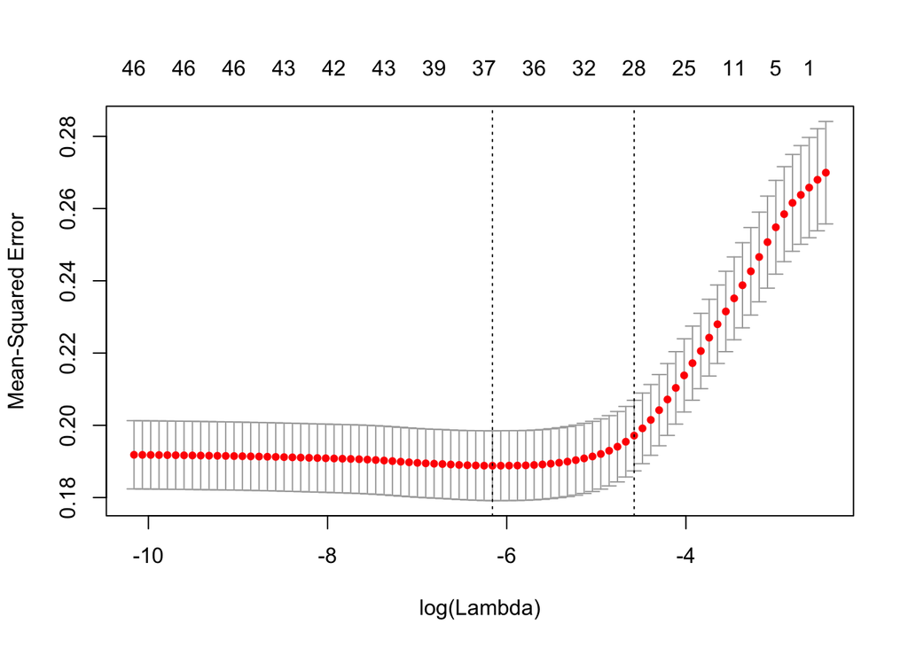

```r
#Begin Logistic Regression with Lasso
#convert training data to matrix format
set.seed(123)
x <- model.matrix(emp_train$Attrition~.,emp_train[,c(cols.CatGLM)])
y <- ifelse(emp_train$Attrition=="Yes",1,0)
# Run Base Model
glm.lasso.new <- cv.glmnet(x,y,alpha=1,family="binomial",type.measure = "mse")
plot(glm.lasso.new)
```

```r
#min value of lambda
lambda_min <- glm.lasso.new$lambda.min
#best value of lambda
lambda_1se <- glm.lasso.new$lambda.1se
#regression coefficients
glm.lasso.new.coef <- coef(glm.lasso.new,s=lambda_1se)
data.frame(name = glm.lasso.new.coef@Dimnames[[1]][glm.lasso.new.coef@i + 1], coefficient = glm.lasso.new.coef@x)
```

```
##                                name   coefficient
## 1                       (Intercept)  1.5071026023
## 2                               Age -0.0104129673
## 3   BusinessTravelTravel_Frequently  0.5679751924
## 4                         DailyRate -0.0001563157
## 5  DepartmentResearch & Development -0.3175946691
## 6                   DepartmentSales  0.0101192638
## 7                  DistanceFromHome  0.0181403082
## 8           EducationFieldMarketing  0.0664777807
## 9               EducationFieldOther -0.0255696530
## 10   EducationFieldTechnical Degree  0.4419704188
## 11          EnvironmentSatisfaction -0.3050329917
## 12                       GenderMale  0.1548217727
## 13                   JobInvolvement -0.4297487944
## 14     JobRoleLaboratory Technician  0.6614081416
## 15    JobRoleManufacturing Director -0.0282707270
## 16         JobRoleResearch Director -0.5589679652
## 17      JobRoleSales Representative  0.8125101982
## 18                  JobSatisfaction -0.2201139436
## 19              MaritalStatusSingle  0.6026889077
## 20               NumCompaniesWorked  0.0890748733
## 21                      OverTimeYes  1.3690621543
## 22         RelationshipSatisfaction -0.0564621601
## 23                 StockOptionLevel -0.1346097156
## 24                TotalWorkingYears -0.0324705552
## 25            TrainingTimesLastYear -0.0647294624
## 26                  WorkLifeBalance -0.2452690840
## 27               YearsInCurrentRole -0.0427828135
## 28          YearsSinceLastPromotion  0.0753910193
## 29             YearsWithCurrManager -0.0263903970
```

```r
# Get column indecis
cols.lasso.coef <- glm.lasso.new.coef@i
cols.lasso.coef <- cols.lasso.coef[-1] # Remove the intercept

train.reduce = emp_train[,cols.lasso.coef]
train.reduce = train.reduce[,-20]

#Assess Model
glm.assess <- glm(Attrition~.,data = train.reduce, family = "binomial")
summary(glm.assess)
```

```
##
## Call:
## glm(formula = Attrition ~ ., family = "binomial", data = train.reduce)
##
## Deviance Residuals:
##     Min       1Q   Median       3Q      Max
## -1.7261  -0.5498  -0.3276  -0.1633   3.0145
##
## Coefficients: (8 not defined because of singularities)
##                                       Estimate Std. Error z value Pr(>|z|)
## (Intercept)                          1.633e+00  1.450e+00   1.126 0.259981
## BusinessTravelTravel_Frequently      1.657e+00  4.328e-01   3.829 0.000129
## BusinessTravelTravel_Rarely          8.315e-01  4.039e-01   2.059 0.039535
## DepartmentResearch & Development     3.979e-03  6.060e-01   0.007 0.994761
## DepartmentSales                      4.911e-01  6.244e-01   0.787 0.431563
## DistanceFromHome                     3.036e-02  1.087e-02   2.792 0.005236
## Education                            1.738e-02  9.186e-02   0.189 0.849927
## EducationFieldLife Sciences         -4.156e-01  1.051e+00  -0.395 0.692639
## EducationFieldMarketing             -3.083e-01  1.096e+00  -0.281 0.778580
## EducationFieldMedical               -4.610e-01  1.058e+00  -0.436 0.662936
## EducationFieldOther                 -8.971e-01  1.116e+00  -0.804 0.421661
## EducationFieldTechnical Degree       3.297e-01  1.065e+00   0.310 0.756888
## EnvironmentSatisfaction             -4.162e-01  8.755e-02  -4.754 2.00e-06
## HourlyRate                           1.995e-03  4.623e-03   0.432 0.666020
## JobInvolvement                      -6.546e-01  1.289e-01  -5.078 3.82e-07
## JobSatisfaction                     -3.717e-01  8.411e-02  -4.419 9.91e-06
## MaritalStatusMarried                 5.398e-01  2.858e-01   1.889 0.058957
## MaritalStatusSingle                  1.436e+00  2.860e-01   5.019 5.19e-07
## MonthlyRate                         -9.948e-06  1.305e-05  -0.762 0.445887
## OverTimeYes                          1.655e+00  1.955e-01   8.467  < 2e-16
## PerformanceRating                   -7.501e-02  2.627e-01  -0.286 0.775196
## RelationshipSatisfaction            -1.630e-01  8.535e-02  -1.909 0.056247
## TotalWorkingYears                   -7.401e-02  1.935e-02  -3.825 0.000131
## TrainingTimesLastYear               -1.861e-01  7.646e-02  -2.435 0.014907
## YearsAtCompany                       5.778e-02  3.219e-02   1.795 0.072654
## YearsWithCurrManager                -1.336e-01  4.629e-02  -2.885 0.003908
## `BusinessTravel_Non-Travel`                 NA         NA      NA       NA
## `Department_Human Resources`                NA         NA      NA       NA
## `Department_Research & Development`         NA         NA      NA       NA
## Department_Sales                            NA         NA      NA       NA
```

[output cut: 34 more lines]

```
## Department_Sales
## `EducationField_Human Resources`
## EducationField_Medical
## `EducationField_Life Sciences`
## EducationField_Other
## ---
## Signif. codes:  0 '***' 0.001 '**' 0.01 '*' 0.05 '.' 0.1 ' ' 1
##
## (Dispersion parameter for binomial family taken to be 1)
##
##     Null deviance: 1031.48  on 1169  degrees of freedom
## Residual deviance:  773.81  on 1144  degrees of freedom
## AIC: 825.81
##
## Number of Fisher Scoring iterations: 6
```

```r
# Remove Non-Sign Variables
index <- c(2,4,7,9,10,11,13,15:19)
train.reduce.final <- train.reduce[,index]


glm.finalversion <- glm(train.reduce$Attrition~.,data = train.reduce.final, family = "binomial")
summary(glm.finalversion)
```

```
##
## Call:
## glm(formula = train.reduce$Attrition ~ ., family = "binomial",
##     data = train.reduce.final)
##
## Deviance Residuals:
##     Min       1Q   Median       3Q      Max
## -1.7065  -0.5495  -0.3416  -0.1739   3.0886
##
## Coefficients:
##                                 Estimate Std. Error z value Pr(>|z|)
## (Intercept)                      1.26617    0.70396   1.799 0.072075 .
## BusinessTravelTravel_Frequently  1.62937    0.42961   3.793 0.000149 ***
## BusinessTravelTravel_Rarely      0.83255    0.40206   2.071 0.038387 *
## DistanceFromHome                 0.02919    0.01074   2.717 0.006578 **
## EnvironmentSatisfaction         -0.41460    0.08516  -4.868 1.12e-06 ***
## JobInvolvement                  -0.65002    0.12591  -5.162 2.44e-07 ***
## JobSatisfaction                 -0.37959    0.08266  -4.592 4.39e-06 ***
## MaritalStatusMarried             0.54855    0.28311   1.938 0.052680 .
## MaritalStatusSingle              1.44335    0.28297   5.101 3.38e-07 ***
## OverTimeYes                      1.58614    0.19070   8.318  < 2e-16 ***
## RelationshipSatisfaction        -0.16695    0.08406  -1.986 0.047030 *
## TotalWorkingYears               -0.07556    0.01896  -3.985 6.74e-05 ***
## TrainingTimesLastYear           -0.17441    0.07491  -2.328 0.019894 *
## YearsAtCompany                   0.05781    0.03161   1.829 0.067389 .
## YearsWithCurrManager            -0.12754    0.04492  -2.839 0.004519 **
## ---
## Signif. codes:  0 '***' 0.001 '**' 0.01 '*' 0.05 '.' 0.1 ' ' 1
##
## (Dispersion parameter for binomial family taken to be 1)
##
##     Null deviance: 1031.48  on 1169  degrees of freedom
## Residual deviance:  790.81  on 1155  degrees of freedom
## AIC: 820.81
##
## Number of Fisher Scoring iterations: 6
```

```r
#Remove Monthly Rate
train.reduce.final.version <- train.reduce.final[,-6]

#Reassess Model
glm.finalfinal <- glm(train.reduce$Attrition~.,data = train.reduce.final.version, family = "binomial")
summary(glm.finalfinal)
```

```
##
## Call:
## glm(formula = train.reduce$Attrition ~ ., family = "binomial",
##     data = train.reduce.final.version)
##
## Deviance Residuals:
##     Min       1Q   Median       3Q      Max
## -1.7758  -0.5742  -0.3691  -0.2011   3.0544
##
## Coefficients:
##                                 Estimate Std. Error z value Pr(>|z|)
## (Intercept)                      2.10903    0.64902   3.250  0.00116 **
## BusinessTravelTravel_Frequently  1.65976    0.41250   4.024 5.73e-05 ***
## BusinessTravelTravel_Rarely      0.83381    0.38527   2.164  0.03045 *
## DistanceFromHome                 0.02510    0.01045   2.402  0.01629 *
## EnvironmentSatisfaction         -0.42533    0.08323  -5.110 3.22e-07 ***
## JobInvolvement                  -0.66063    0.12169  -5.429 5.68e-08 ***
## JobSatisfaction                 -0.35906    0.08072  -4.448 8.67e-06 ***
## OverTimeYes                      1.51959    0.18471   8.227  < 2e-16 ***
## RelationshipSatisfaction        -0.15570    0.08204  -1.898  0.05771 .
## TotalWorkingYears               -0.07788    0.01879  -4.144 3.41e-05 ***
## TrainingTimesLastYear           -0.16452    0.07313  -2.250  0.02447 *
## YearsAtCompany                   0.04605    0.03081   1.494  0.13509
## YearsWithCurrManager            -0.11105    0.04356  -2.550  0.01079 *
## ---
## Signif. codes:  0 '***' 0.001 '**' 0.01 '*' 0.05 '.' 0.1 ' ' 1
##
## (Dispersion parameter for binomial family taken to be 1)
##
##     Null deviance: 1031.48  on 1169  degrees of freedom
## Residual deviance:  826.83  on 1157  degrees of freedom
## AIC: 852.83
##
## Number of Fisher Scoring iterations: 5
```

```r
glm.finalfinal$coefficients
```

```
##                     (Intercept) BusinessTravelTravel_Frequently
##                      2.10902537                      1.65976133
##     BusinessTravelTravel_Rarely                DistanceFromHome
##                      0.83381424                      0.02510475
##         EnvironmentSatisfaction                  JobInvolvement
##                     -0.42532783                     -0.66062915
##                 JobSatisfaction                     OverTimeYes
##                     -0.35905872                      1.51959223
##        RelationshipSatisfaction               TotalWorkingYears
##                     -0.15569624                     -0.07788303
##           TrainingTimesLastYear                  YearsAtCompany
##                     -0.16451544                      0.04604716
##            YearsWithCurrManager
##                     -0.11105360
```

```r
exp(cbind(coef(glm.finalfinal), confint(glm.finalfinal)))
```

```
##                                               2.5 %     97.5 %
## (Intercept)                     8.2402062 2.2938743 29.4491357
## BusinessTravelTravel_Frequently 5.2580558 2.4356727 12.4089926
## BusinessTravelTravel_Rarely     2.3020827 1.1300236  5.1772887
## DistanceFromHome                1.0254225 1.0044848  1.0465530
## EnvironmentSatisfaction         0.6535555 0.5542340  0.7683807
## JobInvolvement                  0.5165263 0.4059855  0.6545741
## JobSatisfaction                 0.6983333 0.5953772  0.8173264
## OverTimeYes                     4.5703612 3.1912666  6.5891055
## RelationshipSatisfaction        0.8558191 0.7284723  1.0052186
## TotalWorkingYears               0.9250726 0.8900473  0.9582470
## TrainingTimesLastYear           0.8483047 0.7334475  0.9772964
## YearsAtCompany                  1.0471238 0.9838192  1.1109003
## YearsWithCurrManager            0.8948908 0.8222133  0.9757138
```

```r
# Test Model
test <- emp_test
test$final.prob <- predict.glm(glm.finalfinal,test[,-3],type="response")
test$final.predicted <- ifelse(test$final.prob>.5,"Yes","No")
Lassofinal <- confusionMatrix(table(test$final.predicted, test$Attrition))
Lassofinal
```

```
## Confusion Matrix and Statistics
##
##
##        No Yes
##   No  246  37
##   Yes   5  12
##
##                Accuracy : 0.86
##                  95% CI : (0.8155, 0.8972)
##     No Information Rate : 0.8367
##     P-Value [Acc > NIR] : 0.1548
##
##                   Kappa : 0.3052
##  Mcnemar's Test P-Value : 1.724e-06
##
##             Sensitivity : 0.9801
##             Specificity : 0.2449
##          Pos Pred Value : 0.8693
##          Neg Pred Value : 0.7059
##              Prevalence : 0.8367
##          Detection Rate : 0.8200
##    Detection Prevalence : 0.9433
##       Balanced Accuracy : 0.6125
##
##        'Positive' Class : No
##
```

##### Summary Explanation:

The following table outlines the four different models that were used in accuracy order. As you can tell, logistic regression was the most accurate; however, we recommend using the logistic regression using lasso because it is more efficient.

```r
# Prediciton Models
# Review Prediciton Models
LogRegOnly # Log Regression
```

```
## Confusion Matrix and Statistics
##
##      true
## pred   No Yes
##   No  244  32
##   Yes   7  17
##
##                Accuracy : 0.87
##                  95% CI : (0.8266, 0.9059)
##     No Information Rate : 0.8367
##     P-Value [Acc > NIR] : 0.0658297
##
##                   Kappa : 0.4015
##  Mcnemar's Test P-Value : 0.0001215
##
##             Sensitivity : 0.9721
##             Specificity : 0.3469
##          Pos Pred Value : 0.8841
##          Neg Pred Value : 0.7083
##              Prevalence : 0.8367
##          Detection Rate : 0.8133
##    Detection Prevalence : 0.9200
##       Balanced Accuracy : 0.6595
##
##        'Positive' Class : No
##
```

```r
Lassofinal # LogRessions with Lasso
```

```
## Confusion Matrix and Statistics
##
##
##        No Yes
##   No  246  37
##   Yes   5  12
##
##                Accuracy : 0.86
##                  95% CI : (0.8155, 0.8972)
##     No Information Rate : 0.8367
##     P-Value [Acc > NIR] : 0.1548
##
##                   Kappa : 0.3052
##  Mcnemar's Test P-Value : 1.724e-06
##
##             Sensitivity : 0.9801
##             Specificity : 0.2449
##          Pos Pred Value : 0.8693
##          Neg Pred Value : 0.7059
##              Prevalence : 0.8367
##          Detection Rate : 0.8200
##    Detection Prevalence : 0.9433
##       Balanced Accuracy : 0.6125
##
##        'Positive' Class : No
##
```

```r
knnPrediction # kNN
```

```
## Confusion Matrix and Statistics
##
##
## knn.test  No Yes
##      No  251  48
##      Yes   0   1
##
##                Accuracy : 0.84
##                  95% CI : (0.7935, 0.8796)
##     No Information Rate : 0.8367
##     P-Value [Acc > NIR] : 0.4758
##
##                   Kappa : 0.0337
##  Mcnemar's Test P-Value : 1.17e-11
##
##             Sensitivity : 1.00000
##             Specificity : 0.02041
##          Pos Pred Value : 0.83946
##          Neg Pred Value : 1.00000
##              Prevalence : 0.83667
##          Detection Rate : 0.83667
##    Detection Prevalence : 0.99667
##       Balanced Accuracy : 0.51020
##
##        'Positive' Class : No
##
```

```r
kWeightedPrediction # K Weighted
```

```
## Confusion Matrix and Statistics
##
##      prediction
##        No Yes
##   No  251   0
##   Yes  47   2
##
##                Accuracy : 0.8433
##                  95% CI : (0.7972, 0.8826)
##     No Information Rate : 0.9933
##     P-Value [Acc > NIR] : 1
##
##                   Kappa : 0.0665
##  Mcnemar's Test P-Value : 1.949e-11
##
##             Sensitivity : 0.84228
##             Specificity : 1.00000
##          Pos Pred Value : 1.00000
##          Neg Pred Value : 0.04082
##              Prevalence : 0.99333
##          Detection Rate : 0.83667
##    Detection Prevalence : 0.83667
##       Balanced Accuracy : 0.92114
##
##        'Positive' Class : No
##
```

```r
# Create Prediction Summary Table
dt0 <- data.frame(cbind(t(LogRegOnly$overall),t(LogRegOnly$byClass)))
dt0$Type <- as.character("LogRegOnly")
dt1 <- data.frame(cbind(t(knnPrediction$overall),t(knnPrediction$byClass)))
dt1$Type <- as.character("kNN")
dt3 <- data.frame(cbind(t(kWeightedPrediction$overall),t(kWeightedPrediction$byClass)))
dt3$Type <- as.character("kWeighted")
dt4 <- data.frame(cbind(t(Lassofinal$overall),t(Lassofinal$byClass)))
dt4$Type <- as.character("Lassofinal")
SummaryPred <-rbind(dt0, dt1, dt3, dt4)
SummaryPred <- SummaryPred[order(-SummaryPred$Accuracy),]
SummaryPred <- SummaryPred[,c(19,1:18)]
SummaryT <- SummaryPred[,c(1,2,9, 10)]
#SummaryPred  %>%  kable() %>% kable_styling(bootstrap_options = "striped", full_width = F) %>% scroll_box(width = "100%", height = "200px")
SummaryT  %>%  kable() %>% kable_styling(bootstrap_options = "striped", full_width = F) %>% scroll_box(width = "100%", height = "200px")
```

|  | Type | Accuracy | Sensitivity | Specificity |
| --- | --- | --- | --- | --- |
| 1 | LogRegOnly | 0.8700000 | 0.9721116 | 0.3469388 |
| 4 | Lassofinal | 0.8600000 | 0.9800797 | 0.2448980 |
| 3 | kWeighted | 0.8433333 | 0.8422819 | 1.0000000 |
| 2 | kNN | 0.8400000 | 1.0000000 | 0.0204082 |